# Basic Usage

## Overview

The `skater` package provides a collection of analysis and utility functions for **S**NP-based **k**inship **a**nalysis, **t**esting, and **e**valuation as an **R** package. Functions in the package include tools for working with pedigree data, performing relationship degree inference, assessing classification accuracy, and summarizing IBD segment data.

```r
library(skater)
```

## Pedigree parsing and manipulation

Pedigrees define familial relationships in a hierarchical structure.

One of the formats used by PLINK and other genetic analysis tools is the `.fam` file.[^1] A `.fam` file is a tabular format with one row per individual and columns for unique IDs of the mother, father, and the family unit. The package includes `read_fam()` to read files in this format:

```r
famfile <- system.file("extdata", "3gens.fam", package="skater", mustWork=TRUE)
fam <- read_fam(famfile)
fam
# # A tibble: 64 × 6
#    fid      id                dadid             momid               sex affected
#    <chr>    <chr>             <chr>             <chr>             <int>    <int>
#  1 testped1 testped1_g1-b1-s1 0                 0                     1        1
#  2 testped1 testped1_g1-b1-i1 0                 0                     2        1
#  3 testped1 testped1_g2-b1-s1 0                 0                     1        1
#  4 testped1 testped1_g2-b1-i1 testped1_g1-b1-s1 testped1_g1-b1-i1     2        1
#  5 testped1 testped1_g2-b2-s1 0                 0                     1        1
#  6 testped1 testped1_g2-b2-i1 testped1_g1-b1-s1 testped1_g1-b1-i1     2        1
#  7 testped1 testped1_g3-b1-i1 testped1_g2-b1-s1 testped1_g2-b1-i1     2        1
#  8 testped1 testped1_g3-b2-i1 testped1_g2-b2-s1 testped1_g2-b2-i1     1        1
#  9 testped2 testped2_g1-b1-s1 0                 0                     2        1
# 10 testped2 testped2_g1-b1-i1 0                 0                     1        1
# # … with 54 more rows
```

Family structures imported from “.fam” formated files can then be translated to the `pedigree` structure used by the `kinship2` package.[^2] The “fam” format may include multiple families, and the `fam2ped()` function will collapse them all into a `tibble` with one row per family:

```r
peds <- fam2ped(fam)
peds
# # A tibble: 8 × 3
#   fid      data             ped
#   <chr>    <list>           <list>
# 1 testped1 <tibble [8 × 5]> <pedigree>
# 2 testped2 <tibble [8 × 5]> <pedigree>
# 3 testped3 <tibble [8 × 5]> <pedigree>
# 4 testped4 <tibble [8 × 5]> <pedigree>
# 5 testped5 <tibble [8 × 5]> <pedigree>
# 6 testped6 <tibble [8 × 5]> <pedigree>
# 7 testped7 <tibble [8 × 5]> <pedigree>
# 8 testped8 <tibble [8 × 5]> <pedigree>
```

In the example above, the resulting `tibble` is nested by family ID. The `data` column contains the individual family information, while the `ped` column contains the pedigree object for that family. You can unnest any particular family:

```r
peds %>%
  dplyr::filter(fid=="testped1") %>%
  tidyr::unnest(cols=data)
# # A tibble: 8 × 7
#   fid      id                dadid             momid      sex affec…¹ ped
#   <chr>    <chr>             <chr>             <chr>    <int>   <dbl> <list>
# 1 testped1 testped1_g1-b1-s1 <NA>              <NA>         1       1 <pedigree>
# 2 testped1 testped1_g1-b1-i1 <NA>              <NA>         2       1 <pedigree>
# 3 testped1 testped1_g2-b1-s1 <NA>              <NA>         1       1 <pedigree>
# 4 testped1 testped1_g2-b1-i1 testped1_g1-b1-s1 testped…     2       1 <pedigree>
# 5 testped1 testped1_g2-b2-s1 <NA>              <NA>         1       1 <pedigree>
# 6 testped1 testped1_g2-b2-i1 testped1_g1-b1-s1 testped…     2       1 <pedigree>
# 7 testped1 testped1_g3-b1-i1 testped1_g2-b1-s1 testped…     2       1 <pedigree>
# 8 testped1 testped1_g3-b2-i1 testped1_g2-b2-s1 testped…     1       1 <pedigree>
# # … with abbreviated variable name ¹affected
```

You can also look at a single pedigree:

```r
peds$ped[[1]]
# Pedigree object with 8 subjects
# Bit size= 4
```

Or plot that pedigree:

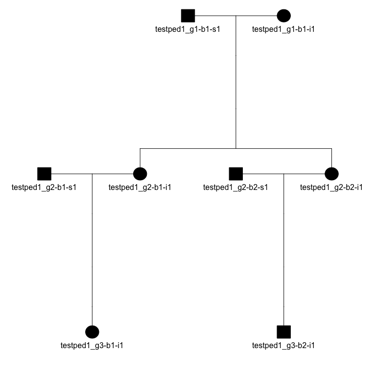

```r
plot(peds$ped[[1]], mar=c(1,4,1,4))
```

The `plot_pedigree()` function from `skater` will iterate over a list of pedigree objects, writing a multi-page PDF, with each page containing a pedigree from family:

```r
plot_pedigree(peds$ped, file="3gens.ped.pdf")
```

The `ped2kinpair()` function takes a pedigree object and produces a pairwise list of relationships between all individuals in the data with the expected kinship coefficients for each pair.

The function can be run on a single family:

```r
ped2kinpair(peds$ped[[1]])
# # A tibble: 36 × 3
#    id1               id2                   k
#    <chr>             <chr>             <dbl>
#  1 testped1_g1-b1-s1 testped1_g1-b1-s1 0.5
#  2 testped1_g1-b1-i1 testped1_g1-b1-s1 0
#  3 testped1_g1-b1-s1 testped1_g2-b1-s1 0
#  4 testped1_g1-b1-s1 testped1_g2-b1-i1 0.25
#  5 testped1_g1-b1-s1 testped1_g2-b2-s1 0
#  6 testped1_g1-b1-s1 testped1_g2-b2-i1 0.25
#  7 testped1_g1-b1-s1 testped1_g3-b1-i1 0.125
#  8 testped1_g1-b1-s1 testped1_g3-b2-i1 0.125
#  9 testped1_g1-b1-i1 testped1_g1-b1-i1 0.5
# 10 testped1_g1-b1-i1 testped1_g2-b1-s1 0
# # … with 26 more rows
```

Or mapped over all families in the pedigree

```r
kinpairs <-
  peds %>%
  dplyr::mutate(pairs=purrr::map(ped, ped2kinpair)) %>%
  dplyr::select(fid, pairs) %>%
  tidyr::unnest(cols=pairs)
kinpairs
# # A tibble: 288 × 4
#    fid      id1               id2                   k
#    <chr>    <chr>             <chr>             <dbl>
#  1 testped1 testped1_g1-b1-s1 testped1_g1-b1-s1 0.5
#  2 testped1 testped1_g1-b1-i1 testped1_g1-b1-s1 0
#  3 testped1 testped1_g1-b1-s1 testped1_g2-b1-s1 0
#  4 testped1 testped1_g1-b1-s1 testped1_g2-b1-i1 0.25
#  5 testped1 testped1_g1-b1-s1 testped1_g2-b2-s1 0
#  6 testped1 testped1_g1-b1-s1 testped1_g2-b2-i1 0.25
#  7 testped1 testped1_g1-b1-s1 testped1_g3-b1-i1 0.125
#  8 testped1 testped1_g1-b1-s1 testped1_g3-b2-i1 0.125
#  9 testped1 testped1_g1-b1-i1 testped1_g1-b1-i1 0.5
# 10 testped1 testped1_g1-b1-i1 testped1_g2-b1-s1 0
# # … with 278 more rows
```

Note that this maps `ped2kinpair()` over all `ped` objects in the input `tibble`, and that relationships are not shown for between-family relationships (which should all be zero).

## Degree Inference

The `skater` package includes functions to translate kinship coefficients to relationship degrees. The kinship coefficients could come from `ped2kinpair()` or other kinship estimation software.

The `dibble()` function creates a **d**egree **i**nference `tibble`, with degrees up to the specified `max_degree` (default=3), expected kinship coefficient, and lower (`l`) and upper (`u`) inference ranges as defined in the KING paper.[^3] Degree 0 corresponds to self / identity / monozygotic twins, with an expected kinship coefficient of 0.5, with inference range >=0.354. Anything beyond the maximum degree resolution is considered unrelated (degree `NA`), with expected kinship coefficient of 0.

```r
dibble()
# # A tibble: 5 × 4
#   degree      k       l      u
#    <int>  <dbl>   <dbl>  <dbl>
# 1      0 0.5     0.354  1
# 2      1 0.25    0.177  0.354
# 3      2 0.125   0.0884 0.177
# 4      3 0.0625  0.0442 0.0884
# 5     NA 0      -1      0.0442
```

The degree inference `max_degree` default is 3. Change this argument to allow more granular degree inference ranges:

```r
dibble(max_degree = 5)
# # A tibble: 7 × 4
#   degree      k       l      u
#    <int>  <dbl>   <dbl>  <dbl>
# 1      0 0.5     0.354  1
# 2      1 0.25    0.177  0.354
# 3      2 0.125   0.0884 0.177
# 4      3 0.0625  0.0442 0.0884
# 5      4 0.0312  0.0221 0.0442
# 6      5 0.0156  0.0110 0.0221
# 7     NA 0      -1      0.0110
```

Note that the distance between relationship degrees becomes smaller as the relationship degree becomes more distant. The `dibble()` function will throw a warning with `max_degree` >=10, and will stop with an error at >=12.

The `kin2degree()` function infers the relationship degree given a kinship coefficient and a `max_degree` up to which anything more distant is treated as unrelated. Example first degree relative:

```r
kin2degree(.25, max_degree=3)
# [1] 1
```

Example 4th degree relative, but using the default max_degree resolution of 3:

```r
kin2degree(.0312, max_degree=3)
# [1] NA
```

Example 4th degree relative, but increasing the degree resolution:

```r
kin2degree(.0312, max_degree=5)
# [1] 4
```

The `kin2degree()` function is vectorized over values of `k`, so it can be used inside of a `mutate` on a `tibble` of kinship coefficients:

```r
# Get two pairs from each type of relationship we have in kinpairs:
kinpairs_subset <-
  kinpairs %>%
  dplyr::group_by(k) %>%
  dplyr::slice(1:2)
kinpairs_subset
# # A tibble: 10 × 4
# # Groups:   k [5]
#    fid      id1               id2                    k
#    <chr>    <chr>             <chr>              <dbl>
#  1 testped1 testped1_g1-b1-i1 testped1_g1-b1-s1 0
#  2 testped1 testped1_g1-b1-s1 testped1_g2-b1-s1 0
#  3 testped1 testped1_g3-b1-i1 testped1_g3-b2-i1 0.0625
#  4 testped2 testped2_g3-b1-i1 testped2_g3-b2-i1 0.0625
#  5 testped1 testped1_g1-b1-s1 testped1_g3-b1-i1 0.125
#  6 testped1 testped1_g1-b1-s1 testped1_g3-b2-i1 0.125
#  7 testped1 testped1_g1-b1-s1 testped1_g2-b1-i1 0.25
#  8 testped1 testped1_g1-b1-s1 testped1_g2-b2-i1 0.25
#  9 testped1 testped1_g1-b1-s1 testped1_g1-b1-s1 0.5
# 10 testped1 testped1_g1-b1-i1 testped1_g1-b1-i1 0.5

# Infer degree out to third degree relatives:
kinpairs_subset %>%
  dplyr::mutate(degree=kin2degree(k, max_degree=3))
# # A tibble: 10 × 5
# # Groups:   k [5]
#    fid      id1               id2                    k degree
#    <chr>    <chr>             <chr>              <dbl>  <int>
#  1 testped1 testped1_g1-b1-i1 testped1_g1-b1-s1 0          NA
#  2 testped1 testped1_g1-b1-s1 testped1_g2-b1-s1 0          NA
#  3 testped1 testped1_g3-b1-i1 testped1_g3-b2-i1 0.0625      3
#  4 testped2 testped2_g3-b1-i1 testped2_g3-b2-i1 0.0625      3
#  5 testped1 testped1_g1-b1-s1 testped1_g3-b1-i1 0.125       2
#  6 testped1 testped1_g1-b1-s1 testped1_g3-b2-i1 0.125       2
#  7 testped1 testped1_g1-b1-s1 testped1_g2-b1-i1 0.25        1
#  8 testped1 testped1_g1-b1-s1 testped1_g2-b2-i1 0.25        1
#  9 testped1 testped1_g1-b1-s1 testped1_g1-b1-s1 0.5         0
# 10 testped1 testped1_g1-b1-i1 testped1_g1-b1-i1 0.5         0
```

## Benchmarking Degree Classification

Once estimated kinship is converted to degree, it may be of interest to compare the inferred degree to truth. When aggregated over many relationships and inferences, this method can help benchmark performance of a particular kinship analysis method.

The `skater` package adapts functionality from the `confusionMatrix` package[^4] in the `confusion_matrix()` function.

1. A `tibble` with calculated accuracy, lower and upper bounds, the guessing rate and p-value of the accuracy vs. the guessing rate.
2. A `tibble` with the following statistics (for each class):
   - Sensitivity = A/(A+C)
   - Specificity = D/(B+D)
   - Prevalence = (A+C)/(A+B+C+D)
   - PPV = (sensitivity * prevalence)/((sensitivity * prevalence) + ((1-specificity) * (1-prevalence)))
   - NPV = (specificity * (1-prevalence))/(((1-sensitivity) * prevalence) + ((specificity) * (1-prevalence)))
   - Detection Rate = A/(A+B+C+D)
   - Detection Prevalence = (A+B)/(A+B+C+D)
   - Balanced Accuracy = (sensitivity+specificity)/2
   - Precision = A/(A+B)
   - Recall = A/(A+C)
   - F1 = harmonic mean of precision and recall
   - False Discovery Rate = 1 - PPV
   - False Omission Rate = 1 - NPV
   - False Positive Rate = 1 - Specificity
   - False Negative Rate = 1 - Sensitivity
3. A `matrix` with the contingency table object itself.
4. A `vector` with the reciprocal RMSE (R-RMSE). The R-RMSE is calculated as `sqrt(mean((1/(Target+.5)-1/(Predicted+.5))^2)))`, and is a superior measure to classification accuracy when benchmarking relationship degree estimation. Taking the reciprocal of the target and predicted degree results in larger penalties for more egregious misclassifications (e.g., classifying a first-degree relative pair as second degree) than misclassifications at more distant relationships (e.g., misclassifying a fourth-degree relative pair as fifth-degree). The +0.5 adjustment prevents division-by-zero when a 0th-degree (identical) relative pair is introduced.

To illustrate the usage, first take the `kinpairs` data from above and randomly flip ~20% of the true relationship degrees.

```r
# Function to randomly flip levels of a factor (at 20%, by default)
randomflip <- function(x, p=.2) ifelse(runif(length(x))<p, sample(unique(x)), x)

# Infer degree (truth/target) using kin2degree, then randomly flip 20% of them
set.seed(42)
kinpairs_inferred <- kinpairs %>%
  dplyr::mutate(degree_truth=kin2degree(k, max_degree=3)) %>%
  dplyr::mutate(degree_truth=as.character(degree_truth)) %>%
  dplyr::mutate(degree_truth=tidyr::replace_na(degree_truth, "unrelated")) %>%
  dplyr::mutate(degree_inferred=randomflip(degree_truth))
kinpairs_inferred
# # A tibble: 288 × 6
#    fid      id1               id2                   k degree_truth degree_infe…¹
#    <chr>    <chr>             <chr>             <dbl> <chr>        <chr>
#  1 testped1 testped1_g1-b1-s1 testped1_g1-b1-s1 0.5   0            0
#  2 testped1 testped1_g1-b1-i1 testped1_g1-b1-s1 0     unrelated    unrelated
#  3 testped1 testped1_g1-b1-s1 testped1_g2-b1-s1 0     unrelated    unrelated
#  4 testped1 testped1_g1-b1-s1 testped1_g2-b1-i1 0.25  1            1
#  5 testped1 testped1_g1-b1-s1 testped1_g2-b2-s1 0     unrelated    unrelated
#  6 testped1 testped1_g1-b1-s1 testped1_g2-b2-i1 0.25  1            1
#  7 testped1 testped1_g1-b1-s1 testped1_g3-b1-i1 0.125 2            2
#  8 testped1 testped1_g1-b1-s1 testped1_g3-b2-i1 0.125 2            1
#  9 testped1 testped1_g1-b1-i1 testped1_g1-b1-i1 0.5   0            0
# 10 testped1 testped1_g1-b1-i1 testped1_g2-b1-s1 0     unrelated    unrelated
# # … with 278 more rows, and abbreviated variable name ¹degree_inferred
```

```r
confusion_matrix(prediction = kinpairs_inferred$degree_inferred,
                 target = kinpairs_inferred$degree_truth)
# $Accuracy
# # A tibble: 1 × 5
#   Accuracy `Accuracy LL` `Accuracy UL` `Accuracy Guessing` `Accuracy P-value`
#      <dbl>         <dbl>         <dbl>               <dbl>              <dbl>
# 1    0.812         0.763         0.856               0.333           1.09e-62
#
# $Other
# # A tibble: 6 × 15
#   Class         N Sensit…¹ Speci…² PPV/P…³   NPV F1/Di…⁴ Preva…⁵ Detec…⁶ Detec…⁷
#   <chr>     <dbl>    <dbl>   <dbl>   <dbl> <dbl>   <dbl>   <dbl>   <dbl>   <dbl>
# 1 0          64      0.75    0.964   0.857 0.931   0.8    0.222   0.167   0.194
# 2 1          72      0.806   0.944   0.829 0.936   0.817  0.25    0.201   0.243
# 3 2          48      0.833   0.967   0.833 0.967   0.833  0.167   0.139   0.167
# 4 3           8      0.75    0.936   0.25  0.992   0.375  0.0278  0.0208  0.0833
# 5 unrelated  96      0.854   0.958   0.911 0.929   0.882  0.333   0.285   0.312
# 6 Average    57.6    0.799   0.954   0.736 0.951   0.741  0.2     0.162   0.2
# # … with 5 more variables: `Balanced Accuracy` <dbl>, FDR <dbl>, FOR <dbl>,
# #   `FPR/Fallout` <dbl>, FNR <dbl>, and abbreviated variable names
# #   ¹`Sensitivity/Recall/TPR`, ²`Specificity/TNR`, ³`PPV/Precision`,
# #   ⁴`F1/Dice`, ⁵Prevalence, ⁶`Detection Rate`, ⁷`Detection Prevalence`
#
# $Table
#            Target
# Predicted    0  1  2  3 unrelated
#   0         48  4  2  1         1
#   1          5 58  4  0         3
#   2          0  3 40  1         4
#   3          8  4  0  6         6
#   unrelated  3  3  2  0        82
#
# $recip_rmse
# [1] 0.4665971
```

You can use `purrr::pluck()` to isolate just the contingency table:

```r
confusion_matrix(prediction = kinpairs_inferred$degree_inferred,
                 target = kinpairs_inferred$degree_truth) %>%
  purrr::pluck("Table")
#            Target
# Predicted    0  1  2  3 unrelated
#   0         48  4  2  1         1
#   1          5 58  4  0         3
#   2          0  3 40  1         4
#   3          8  4  0  6         6
#   unrelated  3  3  2  0        82
```

Or optionally output in a tidy (`longer=TRUE`) format, then spread stats by class:

```r
confusion_matrix(prediction = kinpairs_inferred$degree_inferred,
                 target = kinpairs_inferred$degree_truth,
                 longer = TRUE) %>%
  purrr::pluck("Other") %>%
  tidyr::spread(Class, Value) %>%
  dplyr::relocate(Average, .after=dplyr::last_col()) %>%
  dplyr::mutate_if(rlang::is_double, signif, 2) %>%
  knitr::kable()
```

| Statistic | 0 | 1 | 2 | 3 | unrelated | Average |
| --- | --- | --- | --- | --- | --- | --- |
| Balanced Accuracy | 0.860 | 0.880 | 0.900 | 0.8400 | 0.910 | 0.880 |
| Detection Prevalence | 0.190 | 0.240 | 0.170 | 0.0830 | 0.310 | 0.200 |
| Detection Rate | 0.170 | 0.200 | 0.140 | 0.0210 | 0.280 | 0.160 |
| F1/Dice | 0.800 | 0.820 | 0.830 | 0.3800 | 0.880 | 0.740 |
| FDR | 0.140 | 0.170 | 0.170 | 0.7500 | 0.089 | 0.260 |
| FNR | 0.250 | 0.190 | 0.170 | 0.2500 | 0.150 | 0.200 |
| FOR | 0.069 | 0.064 | 0.033 | 0.0076 | 0.071 | 0.049 |
| FPR/Fallout | 0.036 | 0.056 | 0.033 | 0.0640 | 0.042 | 0.046 |
| N | 64.000 | 72.000 | 48.000 | 8.0000 | 96.000 | 58.000 |
| NPV | 0.930 | 0.940 | 0.970 | 0.9900 | 0.930 | 0.950 |
| PPV/Precision | 0.860 | 0.830 | 0.830 | 0.2500 | 0.910 | 0.740 |
| Prevalence | 0.220 | 0.250 | 0.170 | 0.0280 | 0.330 | 0.200 |
| Sensitivity/Recall/TPR | 0.750 | 0.810 | 0.830 | 0.7500 | 0.850 | 0.800 |
| Specificity/TNR | 0.960 | 0.940 | 0.970 | 0.9400 | 0.960 | 0.950 |

## IBD Segment Analysis

Tools such as `hap-ibd`[^5] are capable of inferring shared IBD segments between individuals. The `skater` package includes functionality to take those IBD segments, compute shared genomic centimorgan (cM) length, and convert that shared cM to a kinship coefficient. In addition to inferred segments, these functions can estimate “truth” kinship from data simulated by `ped-sim`.[^6]

The `read_ibd()` function reads in the pairwise IBD segment format. Input to this function can either be inferred IBD segments from hap-IBD (`source="hapibd"`) or simulated segments (`source="pedsim"`). The first example below uses data in the `hap-ibd` output format:

```r
hapibd_fp <- system.file("extdata", "GBR.sim.ibd.gz", package="skater", mustWork=TRUE)
hapibd_seg <- read_ibd(hapibd_fp, source = "hapibd")
# New names:
# • `1` -> `1...2`
# • `1` -> `1...4`
# • `1` -> `1...5`
hapibd_seg
# # A tibble: 3,954 × 6
#    id1               id2                 chr     start       end length
#    <chr>             <chr>             <dbl>     <dbl>     <dbl>  <dbl>
#  1 testped1_g1-b1-s1 testped1_g3-b1-i1     1 197661576 234863602   47.1
#  2 testped1_g2-b2-i1 testped1_g3-b1-i1     1 197661576 231017545   39.8
#  3 testped1_g3-b1-i1 testped1_g3-b2-i1     1 197661576 212799139   20.3
#  4 testped3_g1-b1-s1 testped3_g3-b2-i1     1   2352146  10862397   17.7
#  5 testped3_g2-b2-i1 testped3_g3-b2-i1     1   2352146  10862397   17.7
#  6 testped1_g1-b1-s1 testped1_g2-b1-i1     1   3328659  64123868   86.4
#  7 testped1_g1-b1-s1 testped1_g3-b1-i1     1   3328659  33476811   51.2
#  8 testped1_g2-b2-s1 testped1_g3-b2-i1     1   5003504  32315147   45.9
#  9 testped2_g1-b1-i1 testped2_g3-b1-i1     1 240810528 248578622   15.9
# 10 testped2_g1-b1-i1 testped2_g2-b2-i1     1 241186056 249170711   15.5
# # … with 3,944 more rows
```

In order to translate the shared genomic cM length to a kinship coefficient, you must load a genetic map with `read_map()`. Software for IBD segment inference and simulation requires a genetic map. The map loaded for kinship estimation should be the same one used for creating the shared IBD segment output. The example below uses a minimal genetic map created with `min_map`[^7] that ships with `skater`:

```r
gmapfile <- system.file("extdata", "sexspec-avg-min.plink.map", package="skater", mustWork=TRUE)
gmap <- read_map(gmapfile)
gmap
# # A tibble: 28,726 × 3
#      chr  value      bp
#    <dbl>  <dbl>   <dbl>
#  1     1 0       752721
#  2     1 0.0292 1066029
#  3     1 0.0829 1099342
#  4     1 0.157  1106473
#  5     1 0.246  1152631
#  6     1 0.294  1314015
#  7     1 0.469  1510801
#  8     1 0.991  1612540
#  9     1 1.12   1892325
# 10     1 1.41   1916587
# # … with 28,716 more rows
```

The `ibd2kin()` function takes the segments and map file and outputs a `tibble` with one row per pair of individuals and columns for individual 1 ID, individual 2 ID, and the kinship coefficient for the pair:

```r
ibd_dat <- ibd2kin(.ibd_data=hapibd_seg, .map=gmap)
ibd_dat
# # A tibble: 196 × 3
#    id1               id2                kinship
#    <chr>             <chr>                <dbl>
#  1 testped1_g1-b1-i1 testped1_g1-b1-s1 0.000316
#  2 testped1_g1-b1-i1 testped1_g2-b1-i1 0.261
#  3 testped1_g1-b1-i1 testped1_g2-b2-i1 0.263
#  4 testped1_g1-b1-i1 testped1_g2-b2-s1 0.000150
#  5 testped1_g1-b1-i1 testped1_g3-b1-i1 0.145
#  6 testped1_g1-b1-i1 testped1_g3-b2-i1 0.133
#  7 testped1_g1-b1-i1 testped2_g1-b1-i1 0.000165
#  8 testped1_g1-b1-i1 testped2_g1-b1-s1 0.000323
#  9 testped1_g1-b1-i1 testped2_g2-b1-i1 0.000499
# 10 testped1_g1-b1-i1 testped2_g2-b1-s1 0.000318
# # … with 186 more rows
```

As noted above, the IBD segment kinship estimation can be performed on simulated segments. The package includes an example of IBD data in that format:

```r
pedsim_fp <- system.file("extdata", "GBR.sim.seg.gz", package="skater", mustWork=TRUE)
pedsim_seg <- read_ibd(pedsim_fp, source = "pedsim")
pedsim_seg
# $IBD1
# # A tibble: 1,553 × 6
#    id1               id2               chr    start       end length
#    <chr>             <chr>             <chr>  <int>     <int>  <dbl>
#  1 testped1_g1-b1-s1 testped1_g2-b1-i1 1     752721 249170711   262.
#  2 testped1_g1-b1-s1 testped1_g2-b1-i1 2     118913 243043959   249.
#  3 testped1_g1-b1-s1 testped1_g2-b1-i1 3     108226 197800244   217.
#  4 testped1_g1-b1-s1 testped1_g2-b1-i1 4     167596 190936728   200.
#  5 testped1_g1-b1-s1 testped1_g2-b1-i1 5     157856 180692833   196.
#  6 testped1_g1-b1-s1 testped1_g2-b1-i1 6     183917 170981684   184.
#  7 testped1_g1-b1-s1 testped1_g2-b1-i1 7      46239 159119486   176.
#  8 testped1_g1-b1-s1 testped1_g2-b1-i1 8     113565 146280471   160.
#  9 testped1_g1-b1-s1 testped1_g2-b1-i1 9     212908 141027939   154.
# 10 testped1_g1-b1-s1 testped1_g2-b1-i1 10    158946 135473442   166.
# # … with 1,543 more rows
#
# $IBD2
# # A tibble: 132 × 6
#    id1               id2               chr       start       end length
#    <chr>             <chr>             <chr>     <int>     <int>  <dbl>
#  1 testped1_g2-b1-i1 testped1_g2-b2-i1 1     156666011 162443758  9.43
#  2 testped1_g2-b1-i1 testped1_g2-b2-i1 1     197638290 213685761 20.5
#  3 testped1_g2-b1-i1 testped1_g2-b2-i1 1     243586697 249170711  9.43
#  4 testped1_g2-b1-i1 testped1_g2-b2-i1 2      40779973  67697179 25.7
#  5 testped1_g2-b1-i1 testped1_g2-b2-i1 3      26902677  27840868  0.797
#  6 testped1_g2-b1-i1 testped1_g2-b2-i1 3     186680562 192093520 12.1
#  7 testped1_g2-b1-i1 testped1_g2-b2-i1 4      81060970 100337853 16.7
#  8 testped1_g2-b1-i1 testped1_g2-b2-i1 5      24009109  30217553  4.83
#  9 testped1_g2-b1-i1 testped1_g2-b2-i1 5      31751157 134562539 83.7
# 10 testped1_g2-b1-i1 testped1_g2-b2-i1 5     167835827 168425497  1.15
# # … with 122 more rows
```

Notably, `ped-sim` differentiates IBD1 and IBD2 segments. Given that IBD1 and IBD2 segments are weighted differently in kinship calculation, this should be accounted for in processing. In the example below the shared IBD is calculated separately for IBD1 and IBD2 with `type="IBD1"` and `type="IBD2"` respectively. You can then combine those results and sum the IBD1 and IBD2 kinship coefficients to get the overall kinship coefficient:

```r
ibd1_dat <- ibd2kin(.ibd_data=pedsim_seg$IBD1, .map=gmap, type="IBD1")
ibd2_dat <- ibd2kin(.ibd_data=pedsim_seg$IBD2, .map=gmap, type="IBD2")
dplyr::bind_rows(ibd1_dat,ibd2_dat) %>%
  dplyr::group_by(id1,id2) %>%
  dplyr::summarise(kinship = sum(kinship), .groups = "drop")
# # A tibble: 48 × 3
#    id1               id2               kinship
#    <chr>             <chr>               <dbl>
#  1 testped1_g1-b1-i1 testped1_g2-b1-i1   0.245
#  2 testped1_g1-b1-i1 testped1_g2-b2-i1   0.245
#  3 testped1_g1-b1-i1 testped1_g3-b1-i1   0.136
#  4 testped1_g1-b1-i1 testped1_g3-b2-i1   0.124
#  5 testped1_g1-b1-s1 testped1_g2-b1-i1   0.245
#  6 testped1_g1-b1-s1 testped1_g2-b2-i1   0.245
#  7 testped1_g1-b1-s1 testped1_g3-b1-i1   0.109
#  8 testped1_g1-b1-s1 testped1_g3-b2-i1   0.121
#  9 testped1_g2-b1-i1 testped1_g2-b2-i1   0.254
# 10 testped1_g2-b1-i1 testped1_g3-b1-i1   0.245
# # … with 38 more rows
```

[^1]: https://www.cog-genomics.org/plink/1.9/formats#fam
[^2]: Sinnwell, Jason P., Terry M. Therneau, and Daniel J. Schaid. “The kinship2 R package for pedigree data.” *Human heredity* 78.2 (2014): 91-93.
[^3]: Manichaikul, A., Mychaleckyj, J. C., Rich, S. S., Daly, K., Sale, M., & Chen, W. M. (2010). Robust relationship inference in genome-wide association studies. Bioinformatics (Oxford, England), 26(22), 2867–2873. https://doi.org/10.1093/bioinformatics/btq559
[^4]: https://github.com/m-clark/confusionMatrix
[^5]: https://github.com/browning-lab/hap-ibd#output-files
[^6]: https://github.com/williamslab/ped-sim#output-ibd-segments-file
[^7]: https://github.com/williamslab/min_map